# VPT with Robots

Error-Rates Analysis: Human model

Joel Currie[^1], Katrina Louise McDonough[^2], Agnieszka Wykowska[^3], Maria Elena Giannaccini[^4], Patric Bach[^5]

2024-12-17

# Human Model:

## Effects of Interest:

### Self Theta:

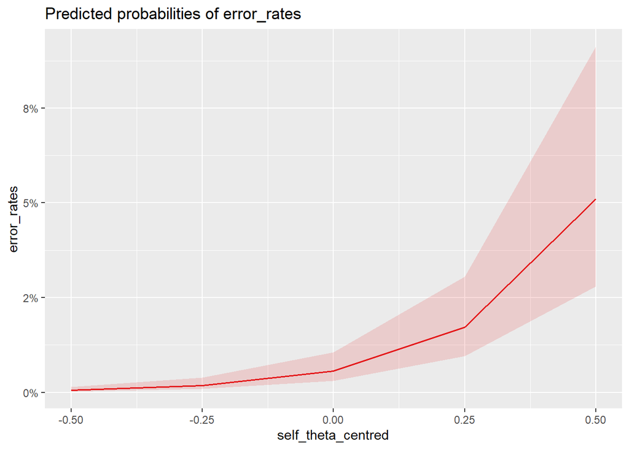

The GLMM model detected a strong $\theta_{self}$ effect ($O.R = 87.9, CI = [25.4 - 304.6], p < .001$), indicating that participants were more likely to make an error correctly identifying characters when they were oriented away from their own perspective, compared to when characters were facing towards them.

### Other Perspective:

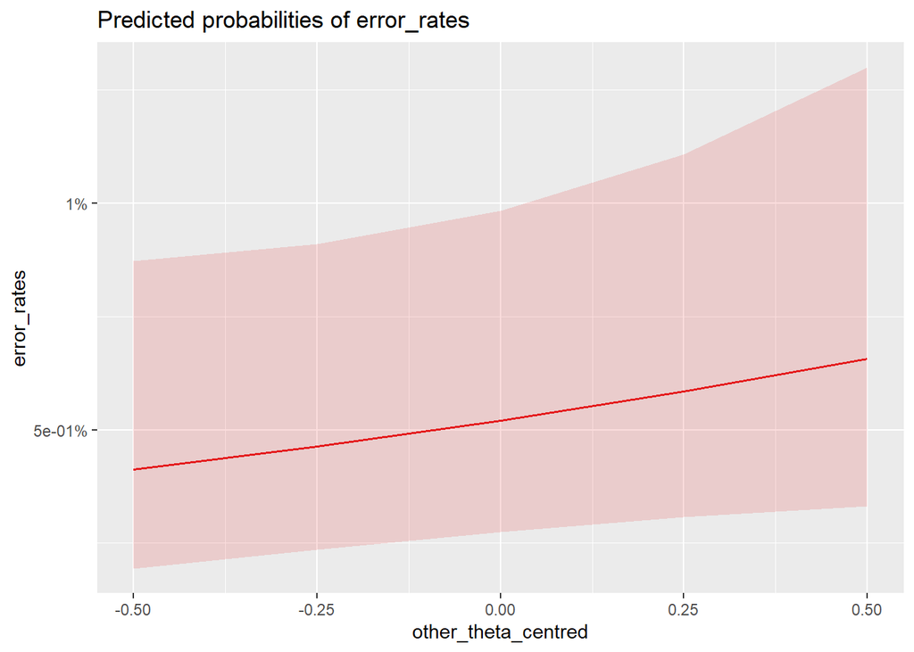

## Other Fixed effects and Interactions:

### Exposure:

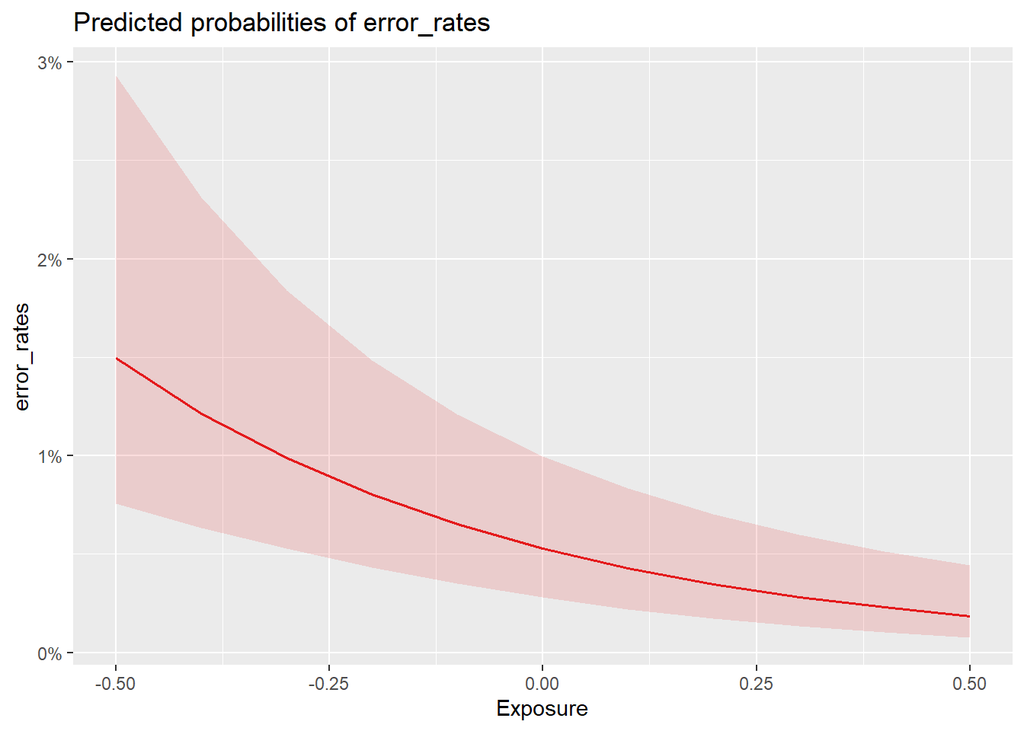

Our model also detected a strong effect of Exposure (Experimental progress), demonstrating that as the experiment progressed participants made less errors: Full-model ($O.R = 0.1, CI = [0.1 - 0.3], p < .001$)

### Self Perspective * Experiment Progress

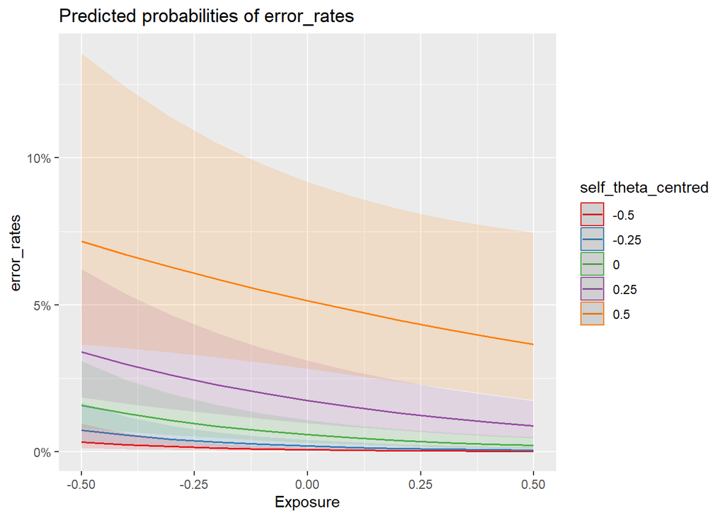

Our model also identified interactions between $\theta_{self}$ and Experiment Progress ($O.R = 14.5, CI = [1.5 - 140.8], p = .021$), indicating that participants disadvantage away from their own perspective decreased over time.

### Other Perspective * Experiment Progress

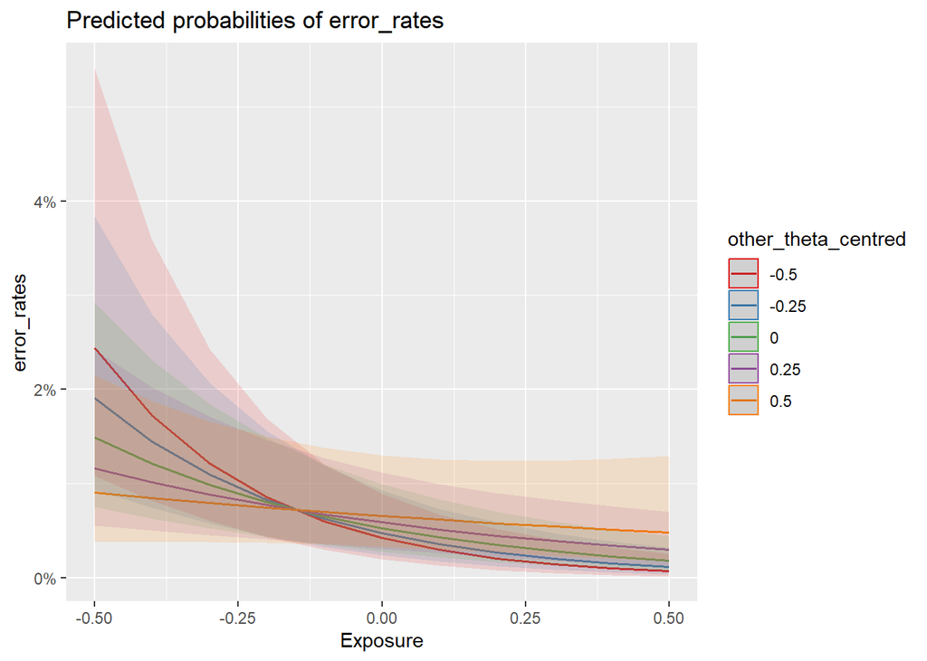

Our model also identified interactions between $\theta_{other}$ and Experiment Progress ($O.R = 18.3, CI = [2.3 - 147.1], p = .006$), indicating that participants initially made more errors against the other participants perspective, however this pattern of data inverts later into the experiment where they show a slight advantage from the other’s perspective.

## Model Construciton:

```r
mod_full_corr <- glmer(error_rates ~ self_theta_centred * Exposure + other_theta_centred * Exposure +
                               (1 + self_theta_centred|subject)
                             ,data = filter(data, Agent == 'Human'), family = binomial, control = glmerControl(optimizer = "bobyqa"))
```

## Output of model:

|  | error_rates |  |  |
| --- | --- | --- | --- |
| Predictors | Odds Ratios | CI | p |
| (Intercept) | 0.01 | 0.00 – 0.01 | **<0.001** |
| self theta centred | 87.92 | 25.38 – 304.58 | **<0.001** |
| Exposure | 0.13 | 0.06 – 0.30 | **<0.001** |
| other theta centred | 1.56 | 0.83 – 2.95 | 0.171 |
| self theta centred × Exposure | 14.50 | 1.49 – 140.79 | **0.021** |
| Exposure × other theta centred | 18.26 | 2.27 – 147.05 | **0.006** |
| Random Effects |  |  |  |
| σ<sup>2</sup> | 3.29 |  |  |
| τ<sub>00</sub> <sub>subject</sub> | 2.17 |  |  |
| τ<sub>11</sub> <sub>subject.self_theta_centred</sub> | 0.84 |  |  |
| ρ<sub>01</sub> <sub>subject</sub> | -0.03 |  |  |
| ICC | 0.41 |  |  |
| N <sub>subject</sub> | 30 |  |  |
| Observations | 6936 |  |  |
| Marginal R<sup>2</sup> / Conditional R<sup>2</sup> | 0.299 / 0.583 |  |  |

[^1]: University of Aberdeen, j.currie.22@abdn.ac.uk
[^2]: University of East Anglia
[^3]: Istituto Italiano di Tecnologia
[^4]: University of Aberdeen
[^5]: University of Aberdeen